# Goal Probability Jags

```r
install.packages("rjags")
```

```
Error in install.packages : Updating loaded packages
```

```r
install.packages("bayesboot")
```

```
Error in install.packages : Updating loaded packages
```

```r
require(rjags)
require(bayesboot)
```

First let’s load and transform the data just like we did on previous python notebook

```r
df <- read.csv("uefa_player_matches.csv", header = TRUE)
df <- df[complete.cases(df), ] # drop na
df <- df[(df$position %in% c("G", "D", "M", "F")),]
position_names <- list("G" = "Goalkeeper", "D" = "Defender", "M" = "Midfield", "F" = "Forward")
df$position <- factor(apply(df['position'], 1, function(x) position_names[[x]]))
df$player_id <- factor(df$player_id)
head(df)
```

|  | match_id | match_date | player | player_id | team | team_id | position | goals |
| --- | --- | --- | --- | --- | --- | --- | --- | --- |
| 1 | 158963 | 2019-06-25T13:00:00+00:00 | Mattia Migani | 80722 | Tre Penne | 700 | Goalkeeper | 0 |
| 2 | 158963 | 2019-06-25T13:00:00+00:00 | Davide Cesarini | 56095 | Tre Penne | 700 | Defender | 0 |
| 5 | 158963 | 2019-06-25T13:00:00+00:00 | Mirko Palazzi | 56099 | Tre Penne | 700 | Defender | 0 |
| 6 | 158963 | 2019-06-25T13:00:00+00:00 | Nicola Gai | 80723 | Tre Penne | 700 | Midfield | 0 |
| 8 | 158963 | 2019-06-25T13:00:00+00:00 | Nicola Chiaruzzi | 80724 | Tre Penne | 700 | Midfield | 0 |
| 9 | 158963 | 2019-06-25T13:00:00+00:00 | Enrico Cibelli | 80725 | Tre Penne | 700 | Midfield | 0 |

Let’s just setup some variable we will need to build our model: y, which means weather there was a goal or not, positions and playerIds

```r
y = apply(df['goals'], 1, function(x) if (x > 0) { 1 } else { 0 })
positions = as.numeric(df$position)
playerIds = as.numeric(df$player_id)
playerIdsUnique = unique(playerIds)
playersMostCommonPositions = c()
for (playerId in playerIdsUnique) {
  playerPositions = df[(playerIds == playerId),]
  sortedPositions = sort(table(as.numeric(playerPositions$position)), decreasing=TRUE)
  playersMostCommonPositions[playerId] <- as.numeric(names(sortedPositions)[1])
}
```

Now the most exciting part, let’s build and compile our hierarchical model!

```r
modelString = "
  model {
    for (positionId in 1:length(positions)) {
      meanPosition[positionId] ~ dunif(0, 1)
      variancePosition[positionId] ~ dunif(0, 1)
    }
    for (i in playerIdsUnique) {
      # Creating a beta distribution based on mean and variance: https://en.wikipedia.org/wiki/Beta_distribution#Mean_and_variance
      mean[i] = meanPosition[playersMostCommonPositions[i]]
      variance[i] = variancePosition[playersMostCommonPositions[i]] / 10
      v[i] = ((mean[i] * (1 - mean[i])) / variance[i]) - 1
      alpha[i] = mean[i] * v[i]
      beta[i] = (1 - mean[i]) * v[i]

      probPlayer[i] ~ dbeta(alpha[i], beta[i])
    }
    for (i in 1:length(y)) {
      y[i] ~ dbern(probPlayer[playerIds[i]])
    }
  }
"
writeLines(modelString, con="TEMPmodel.txt")
jagsModel = jags.model(
  "TEMPmodel.txt",
  data=list(
    y = y,
    positions = positions,
    playerIds = playerIds,
    playerIdsUnique = playerIdsUnique,
    playersMostCommonPositions = playersMostCommonPositions
  )
)
```

So, let me try to explain everything. First of all, our goal is to model the probability of a goal happening or not in a match, so this is clearly a bernoulli trial, which is about true/false results, this is defined by the `y[i] ~ dbern` part. The argument inside dbern is the probability for the given player, but how do we define that?

Player probability of scoring is a beta distribution, as we saw on the previous python notebook. We want to find the probability of scoring for each player, for example, a player with a 0.5 mean probability would probably score every other match. A beta distribution is defined by parameters alpha and beta, but because those are very hard to intuitively interpret, I used a formula to be able to define it based on mean and variance. But who defines this mean and variance then?

The player position! Each position (Forward, Midfield, Defender, Goalkeeper) will have a mean probability of goal that fits for all players, simply defined here by a uninformative uniform distribution between 0 and 1. So the players influence the mean position probability, and the position in turn affects individual players probability to score. This is the magic of Bayes hierarchical models!

```r
update(jagsModel, n.iter=500) # burn-in
parameters = c("probPlayer", "meanPosition", "variancePosition")
codaSamples = coda.samples(jagsModel, variable.names=parameters, n.iter=5000)
```

Alright, so finally, let’s plot our posteriors and start asking questions! What’s the mean probability of a forward player to score in a match?

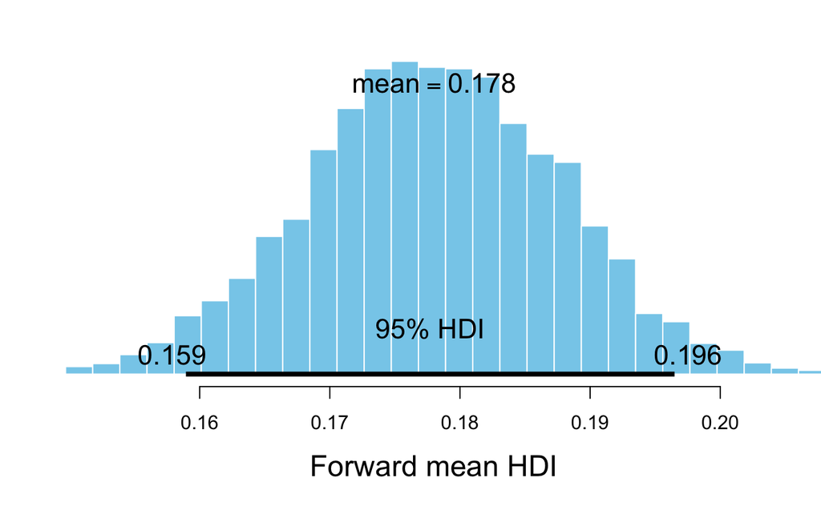

```r
mcmcMat = as.matrix(codaSamples)
positionLevel = which(levels(df$position) == "Forward")
positionMeans = mcmcMat[,paste("meanPosition[", positionLevel, "]", sep="")]
plotPost(positionMeans, credMass=0.95, xlab="Forward mean HDI")
```

Between 0.16 and 0.196, which is a cool advantage of using Bayesian methods, it’s common to look at distributions rather than point estimates, so we can have an idea of our uncertainty. What about Neymar, is he in this range? Or is he conclusively better than average?

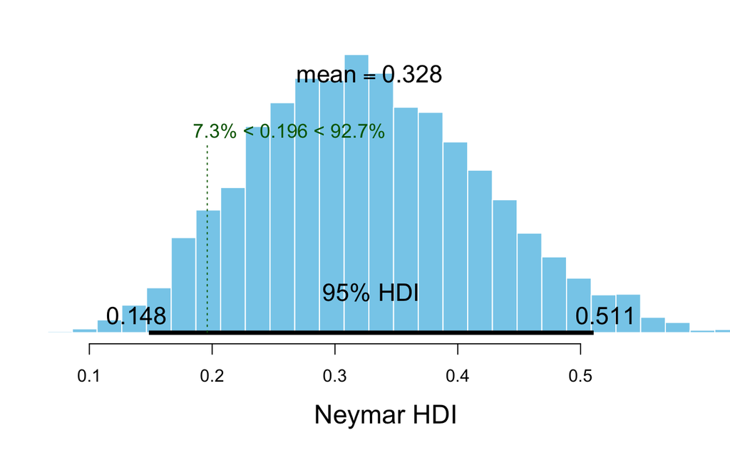

```r
neymarId = 276
neymarLevel = which(levels(df$player_id) == neymarId)
playerProbs = mcmcMat[,paste("probPlayer[", neymarLevel, "]", sep="")]
plotPost(playerProbs, credMass=0.95, xlab="Neymar HDI", compVal=0.196)
```

* considering 95% HDI

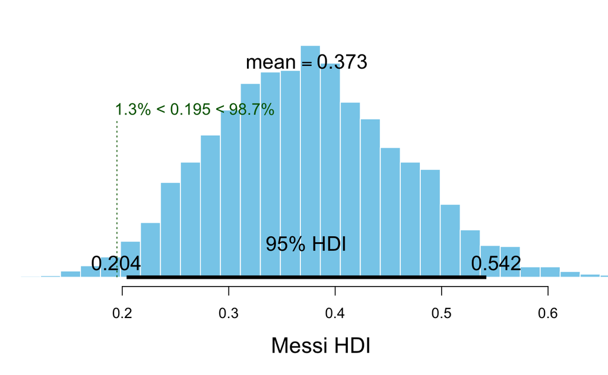

```r
messiId = 154
messiLevel = which(levels(df$player_id) == messiId)
playerProbs = mcmcMat[,paste("probPlayer[", messiLevel, "]", sep="")]
plotPost(playerProbs, credMass=0.95, xlab="Messi HDI", compVal=0.195)
```

That was it, just a small bayesian exercise, I hope it was as fun to you as it was for me.

Disclaimer: I’m not an expert so I may not be interpreting this results correctly, please let me know if I don’t.